# Reproducible Report on COVID19 Data

## Data source and description

The data was retrieved from the GitHub provided by Johns Hopkins University. The two time series datasets are for the US confirmed cases and deaths, reported at the county level. For more details, please visit: https://github.com/CSSEGISandData/COVID-19/tree/master/csse_covid_19_data/csse_covid_19_time_series

## Import data

```r
url_in <- "https://raw.githubusercontent.com/CSSEGISandData/COVID-19/master/csse_covid_19_data/csse_covid_19_time_series/"
file_names <- c ("time_series_covid19_confirmed_US.csv", "time_series_covid19_deaths_US.csv")
urls <- str_c(url_in, file_names)
urls
```

```
## [1] "https://raw.githubusercontent.com/CSSEGISandData/COVID-19/master/csse_covid_19_data/csse_covid_19_time_series/time_series_covid19_confirmed_US.csv"
## [2] "https://raw.githubusercontent.com/CSSEGISandData/COVID-19/master/csse_covid_19_data/csse_covid_19_time_series/time_series_covid19_deaths_US.csv"
```

```r
US_cases <- read_csv(urls[1])
US_deaths <- read_csv(urls[2])
```

## Questions of Interest

Since I live in Alameda County, California, I am interested in finding out the Covid-19 situation in this county. My questions of interest are:

1.What does the cases-per-thousand look like in Alameda County compared to San Mateo County (another county in bay area)?

2.What do the trends of cases and deaths look like in Alameda County?

3.Did the new cases decline in the last 3 months?

## Tidy and Transform data

To answer the above questions, the data was transformed and cleaned so that only the data needed for the analyses was kept.

```r
Two_county_cases <- US_cases %>%
  pivot_longer(cols = -(UID:Combined_Key), names_to = "date", values_to = "cases") %>%
  select(Admin2:cases) %>%
  mutate(date = mdy(date)) %>%
  select(-c(Lat, Long_)) %>%
  subset(Province_State == "California" & (Admin2 == "San Mateo" | Admin2 == "Alameda"))


Two_county_deaths <- US_deaths %>%
  pivot_longer(cols = -(UID:Population), names_to = "date", values_to = "deaths") %>%
  select(Admin2:deaths) %>%
  mutate(date = mdy(date)) %>%
  select(-c(Lat, Long_)) %>%
  subset(Province_State == "California" & (Admin2 == "San Mateo" | Admin2 == "Alameda"))

Two_county <- Two_county_cases %>%
  full_join(Two_county_deaths)
Two_county
```

```
## # A tibble: 1,012 x 8
##    Admin2 Province_State Country_Region Combined_Key date       cases Population
##    <chr>  <chr>          <chr>          <chr>        <date>     <dbl>      <dbl>
##  1 Alame~ California     US             Alameda, Ca~ 2020-01-22     0    1671329
##  2 Alame~ California     US             Alameda, Ca~ 2020-01-23     0    1671329
##  3 Alame~ California     US             Alameda, Ca~ 2020-01-24     0    1671329
##  4 Alame~ California     US             Alameda, Ca~ 2020-01-25     0    1671329
##  5 Alame~ California     US             Alameda, Ca~ 2020-01-26     0    1671329
##  6 Alame~ California     US             Alameda, Ca~ 2020-01-27     0    1671329
##  7 Alame~ California     US             Alameda, Ca~ 2020-01-28     0    1671329
##  8 Alame~ California     US             Alameda, Ca~ 2020-01-29     0    1671329
##  9 Alame~ California     US             Alameda, Ca~ 2020-01-30     0    1671329
## 10 Alame~ California     US             Alameda, Ca~ 2020-01-31     0    1671329
## # ... with 1,002 more rows, and 1 more variable: deaths <dbl>
```

```r
Two_county <- Two_county %>%
mutate(deaths_per_k = deaths * 1000 / Population) %>%
mutate(cases_per_k = cases * 1000 / Population) %>%
select(Admin2, date, cases, deaths, cases_per_k, deaths_per_k, Population) %>%
  rename(County = Admin2) %>%
  subset(cases > 0)
```

## Visualize Data

### Plot 1: Covid-19 Cases-Per-Thousand Comparison Between Alameda County and San Mateo County

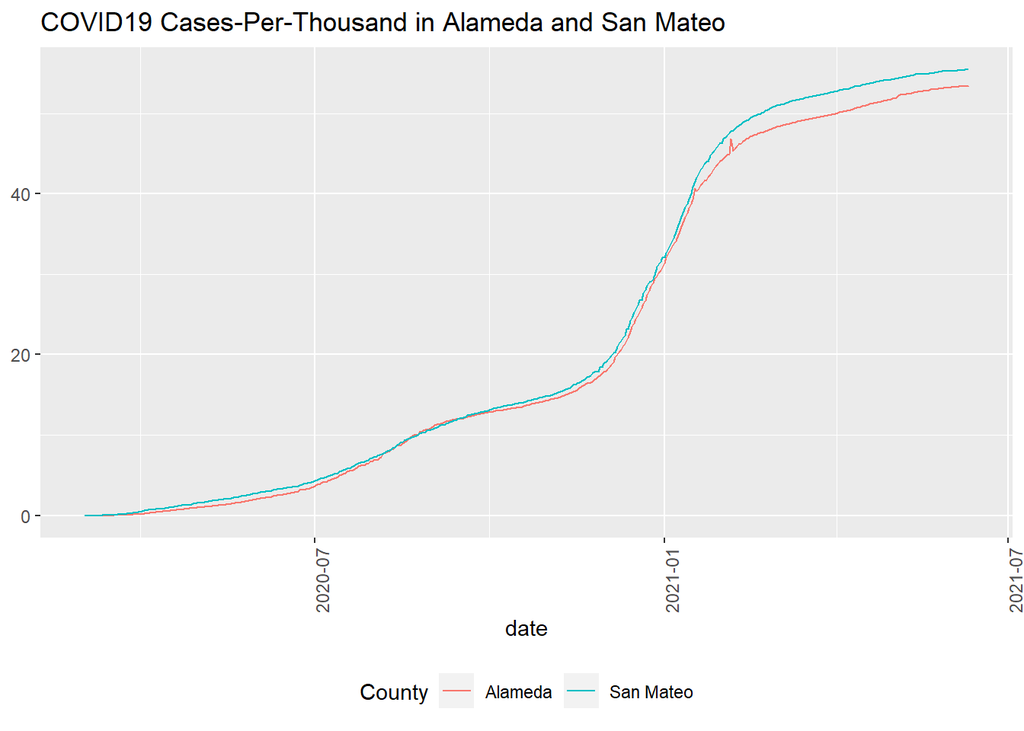

```r
Two_county_compare <- ggplot(data = Two_county, aes(x = date, y = cases_per_k, group = County, color = County)) +
geom_line() +
theme(legend.position="bottom", axis.text.x = element_text(angle = 90)) +
labs(title = "COVID19 Cases-Per-Thousand in Alameda and San Mateo", y = NULL)
Two_county_compare
```

### Plot 2: Covid-19 Cases and Deaths in Alameda County

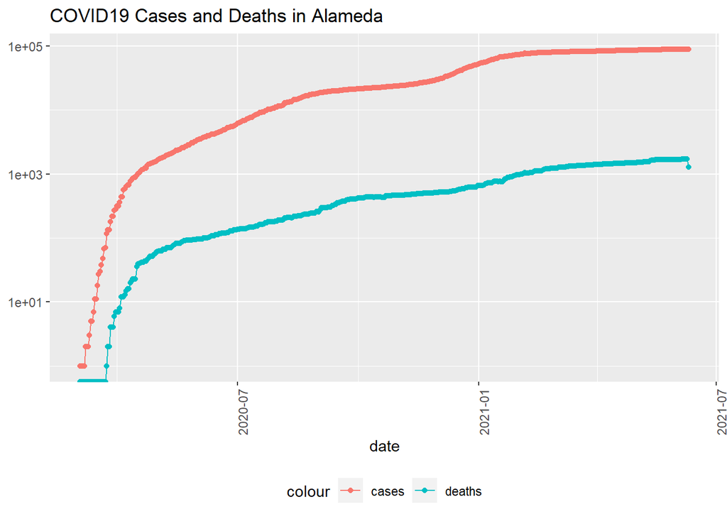

```r
Alameda_county <- Two_county %>%
subset(County == "Alameda")

Alameda_case_death <- ggplot(data = Alameda_county, aes(x = date, y = cases)) +
geom_line(aes(color = "cases")) +
geom_point(aes(color = "cases")) +
geom_line(aes(y = deaths, color = "deaths")) +
geom_point(aes(y = deaths, color = "deaths")) +
scale_y_log10() +
theme(legend.position="bottom", axis.text.x = element_text(angle = 90)) +
labs(title = "COVID19 Cases and Deaths in Alameda", y = NULL)
Alameda_case_death
```